# PAO25_25_09_Python_Visualization

## 7.3 Visualización de correlaciones

• Regresión lineal con variables • Correlaciones numéricas

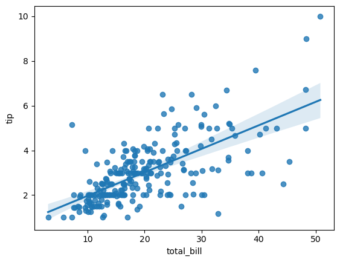

```python
# correlación entre cuenta total y propina, recta regresion e intervalo de confianza
# Regplot ajusta una recta de regresión lineal entre total_bill y tip
sns.regplot(x="total_bill", y="tip", data=tips)
# Muestra la recta de tendencia con banda de confianza
plt.show()
```

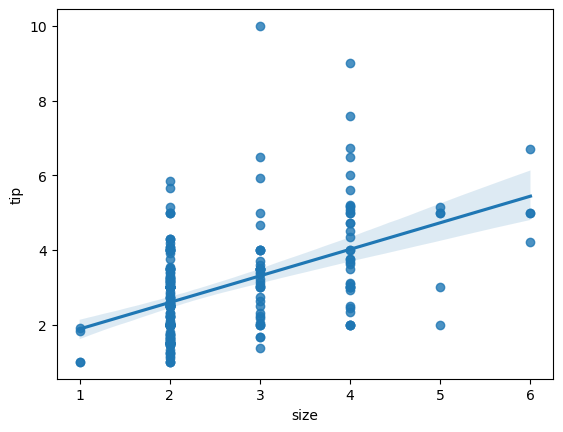

```python
# correlación con valores categóricos (variable discreta, variable debe ser numérica/continua) not a good idea
# Regplot con variable discreta 'size' (número de comensales) — interpretación limitada
sns.regplot(x="size", y="tip", data=tips)
# Renderiza el gráfico (útil como contraejemplo)
plt.show()
```

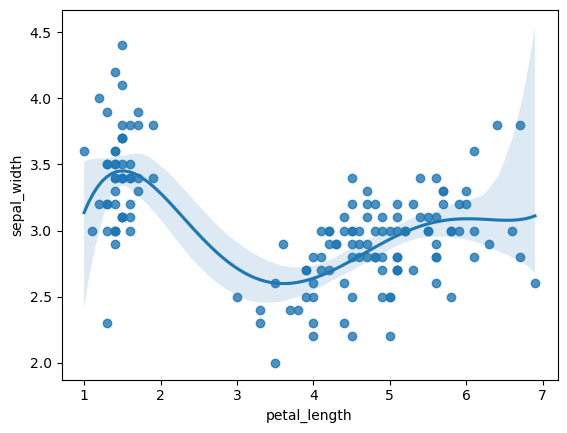

```python
# regresión con polinomios de más grados
# Ajuste polinomial de grado 5 entre longitud de pétalo y ancho de sépalo
sns.regplot(x="petal_length", y="sepal_width", data=iris, order=5)
# Muestra la curva polinomial ajustada a los datos de iris
plt.show()
```

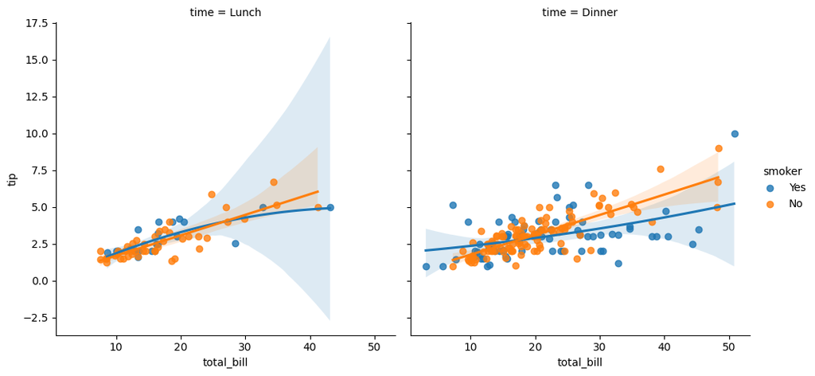

```python
# Correlaciones con varias variables
# Regresión de tip vs total_bill, coloreada por fumador, facetada por franja horaria
sns.lmplot(x="total_bill", y="tip", hue="smoker", data=tips, col="time", order=2)
# Muestra cuadrícula de regresiones polinomiales (grado 2) por subgrupo
plt.show()
```

# 8 Ejercicios

• Representación gráfica con matplotlib y seaborn

## 8.1 matplotlib

• crear una lista de años de 2000 a 2020 (eje x) • generar datos aleatorios para el eje y (hacerlo 4 veces distintas: y0, y1, y2 e y3) • Representar las 4 secuencias de datos aleatorios en una sola figura utilizando matplotlib • Añade una leyenda para poder identificar cada secuencia en el gráfico • Nombra las secuencias de la siguiente forma: "Hawaii", "San Marino", "Islas Feroe", "Guayana" • Representar los mismos datos en 4 subfiguras (axes) distintas, parte de la misma figura • Añade la siguiente info:

- Título: "Datos aleatorios"
- Leyenda
- Nombre del eje x: "Año"
- Nombre del eje y: "GDP" • Añade al menos una anotación (texto y flecha) a uno de los gráficos

## 8.2 Seaborn

• Carga los datos de un dataset de seaborn (distinto a tips, iris o flights) https://github.com/mwaskom/seaborn-data • Si para alguno de los ejercicios no encuentras ejemplos en el dataset, busca otro para completarlo • Recuerda utilizar la versión 'Raw' si se utiliza la URL en el método read_csv • Representa visualmente la relación de cada pareja de atributos (variables) • Escoge una pareja (ambos valores contínuos y numéricos) y demuestra su correlación • Representa los valores de dos variables (x e y, numéricas) en base a otra variable (categórica) • Crea los gráficos que demuestren lo siguiente en el dataset seleccionado:

- La distribución de valores (media, distribución, outliers) de una variable numérica continua
- Compara la distribución de esa variable con otra (contínua y numérica) para representar cuantitativamente la densidad de elementos por valor en ambas variables
- Muestra un ejemplo en el dataset de una variable a la que un modelo de regresión lineal de orden > 1 sea más ajustado que uno de orden == 1